# Example Code making Hypervolumes with means and sd from mixing model results

W. Ryan James

Here is an example for how to use mixing model output data to generate the food web hypervolumes of a restored and a reference oyster bed with 6 species using the means and sd of resource use calculated using `MixSIAR`. Data comes from [Rezek et al. 2017](https://doi.org/10.1007/s00227-017-3084-2). A similar method is described in [James et al. 2019](https://doi.org/10.1016/j.scitotenv.2019.134801).

This script gives examples of how to:

1. Load `MixSIAR` output into R with a custom function
2. Generate points with custom function `HVvalues()` that are z-scored
3. Generate food web hypervolumes using mean and sd mixing model estimates
4. Plot food web hypervolumes
5. Calculate trophic breadth of food web (volume)
6. Calculate food web overlap between two hypervolumes
7. Calculate percent recovery of food web
8. Repeat process to generate confidence intervals

### Load requried packages

```r
library(tidyverse)
library(hypervolume)
```

### Load mixing model data

This is a custom function that was written to import the output of the mixing models

**note** for this to work, all columns must be on the same row like this:

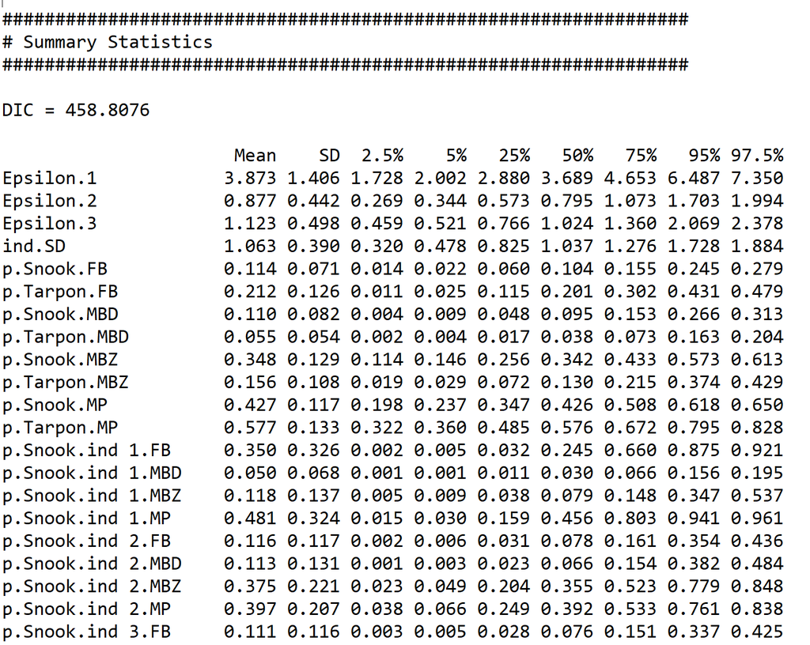

and not wrapped like this:

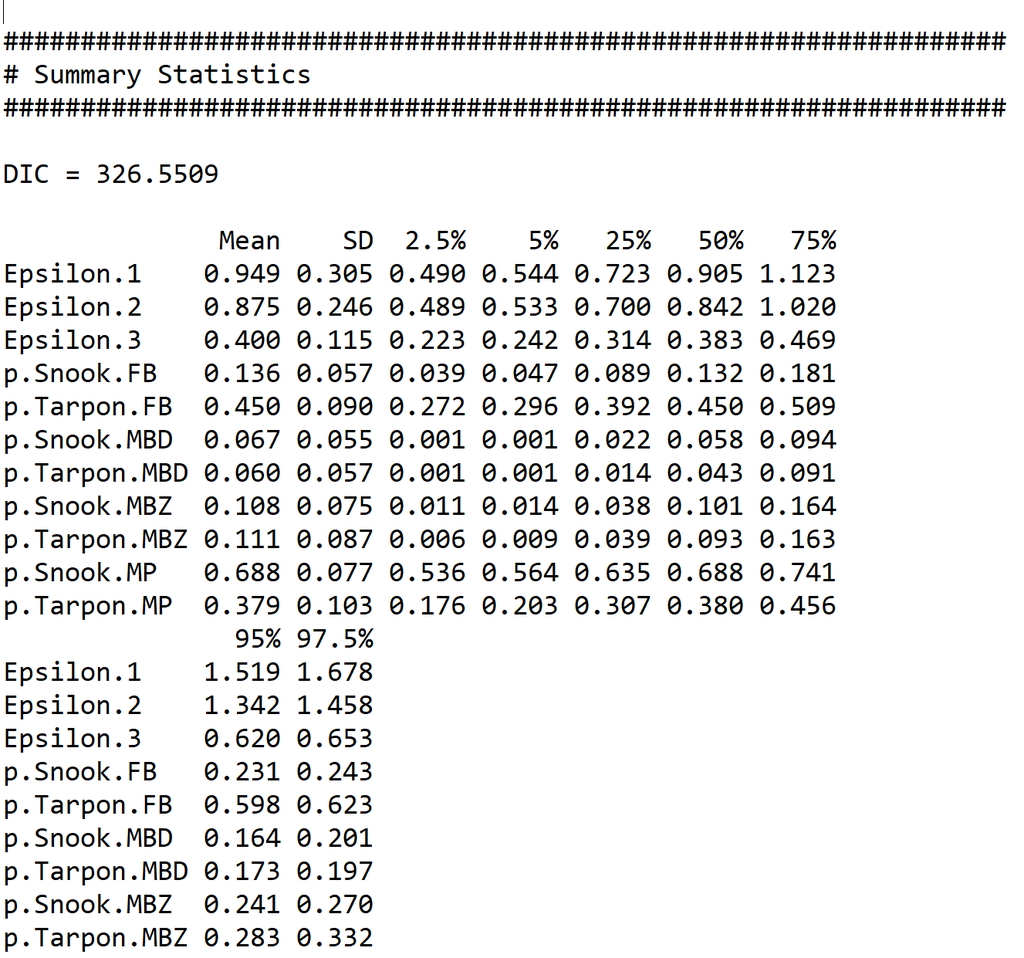

Use the `mixTable` function to load data

`file =` name of name of .txt of summary stats from `MixSIAR`

`site =` ‘site’ or ‘location’ of the data set

`ind = F` if `TRUE` will output with columns as source values, default is `FALSE` and will output data with columns as mean, sd, and posterior distribution quantiles: lowend = 2.5%, highend = 97.5%, mid = 50%, low = 25%, up = 75%, ymax = 75% quantile + 1.5 * IQR, ymin = 25% quantile - 1.5 * IQR

`nest = F` if nested mixing model, `TRUE` will return the sources of nested

```r
mixTable = function(file,site,ind = F,nest = F){
  require(tidyverse)
  cn = c('ID', 'Mean', 'SD', '2.5%', '5%', '25%', '50%', '75%', '95%', '97.5%')
  x = read_table(file, skip = 7,  col_names = T)
  names(x) = cn
  x$source = NA
  x$name = NA
  x$code = NA

  if (nest == F){
    for (i in 1:nrow(x)){
      temp = strsplit(x$ID, split = '.', fixed = T)
      x$source[i] = temp[[i]][3]
      x$name[i] = temp[[i]][2]

      x$site = site
      x$ymax = x$`75%` + 1.5*(x$`75%` - x$`25%`)
      x$ymin = x$`25%` - 1.5*(x$`75%` - x$`25%`)

      df = data.frame(x$name, x$site, x$source, x$Mean, x$SD, x$`2.5%`, x$`97.5%`,
                      x$`50%`, x$`25%`, x$`75%`, x$ymax, x$ymin)
      colnames(df) = c('name', 'site', 'source', 'mean', 'sd', 'lowend', 'highend',
                       'mid', 'low', 'up', 'ymax', 'ymin')
    }
  }else{
    for (i in 1:nrow(x)){
      temp = strsplit(x$ID, split = '.', fixed = T)
      x$source[i] = temp[[i]][4]
      x$code[i] = temp[[i]][3]
      x$name[i] = temp[[i]][2]

      x$site = site
      x$ymax = x$`75%` + 1.5*(x$`75%` - x$`25%`)
      x$ymin = x$`25%` - 1.5*(x$`75%` - x$`25%`)

      df = tibble(x$name, x$site, x$source, x$code, x$Mean, x$SD, x$`2.5%`, x$`97.5%`,
                  x$`50%`, x$`25%`, x$`75%`, x$ymax, x$ymin)
      colnames(df) = c('name', 'site', 'source', 'code', 'mean', 'sd', 'lowend', 'highend',
                       'mid', 'low', 'up', 'ymax', 'ymin')
    }
  }

  for (i in 1:nrow(df)){
    if (df$ymax[i] > df$highend[i]){
      df$ymax[i] = df$highend[i]
    }
    if (df$ymin[i] < df$lowend[i]){
      df$ymin[i] = df$lowend[i]
    }
  }
  df = na.omit(df)
  df = subset(df, name != 'global')

  if (ind == T){
    if (nest == T){
      #df = data.frame(x$name, x$site, x$code, x$source, x$Mean)
      #colnames(df) = c('name', 'site', 'code', 'source', 'mean')
      df = df %>% select(name, site, code, source, mean)
      df = pivot_wider(df, names_from = 'source', values_from = 'mean')
    }else{
      df = df %>% select(name, site, source, mean)
      df = pivot_wider(df, names_from = 'source', values_from = 'mean')
    }
  }

  return(df)
}
```

Example of output

```r
mixTable(file = 'C:/Users/wrjam/Dropbox/WorkDocs/R/Github/ExCode/Hypervolumes/data/OysterRes_ss.txt',
              site = 'Reference',ind = F, nest = F)
```

```
##                        name      site     source  mean    sd lowend highend
## 1               Balanus_spp Reference Gracilaria 0.888 0.089  0.709   0.981
## 2  Costoanachis_semiplicata Reference Gracilaria 0.940 0.095  0.799   0.996
## 3     Crassostrea_virginica Reference Gracilaria 0.734 0.204  0.226   0.988
## 4             Menippe_adina Reference Gracilaria 0.917 0.104  0.692   0.996
## 5              Opsanus_beta Reference Gracilaria 0.945 0.083  0.817   0.996
## 6         Panopeus_herbstii Reference Gracilaria 0.753 0.196  0.254   0.989
## 7               Balanus_spp Reference       SPOM 0.068 0.083  0.002   0.249
## 8  Costoanachis_semiplicata Reference       SPOM 0.039 0.090  0.000   0.167
## 9     Crassostrea_virginica Reference       SPOM 0.156 0.182  0.001   0.662
## 10            Menippe_adina Reference       SPOM 0.053 0.095  0.001   0.268
## 11             Opsanus_beta Reference       SPOM 0.035 0.078  0.000   0.148
## 12        Panopeus_herbstii Reference       SPOM 0.141 0.167  0.001   0.619
## 13              Balanus_spp Reference       SSOM 0.044 0.042  0.001   0.151
## 14 Costoanachis_semiplicata Reference       SSOM 0.022 0.029  0.000   0.094
```

[output cut: 23 more lines]

Same data with `ind = T`

```r
mixTable(file = 'C:/Users/wrjam/Dropbox/WorkDocs/R/Github/ExCode/Hypervolumes/data/OysterRes_ss.txt',
              site = 'Reference',ind = T, nest = F)
```

```
## # A tibble: 6 x 5
##   name                     site      Gracilaria  SPOM  SSOM
##   <chr>                    <chr>          <dbl> <dbl> <dbl>
## 1 Balanus_spp              Reference      0.888 0.068 0.044
## 2 Costoanachis_semiplicata Reference      0.94  0.039 0.022
## 3 Crassostrea_virginica    Reference      0.734 0.156 0.11
## 4 Menippe_adina            Reference      0.917 0.053 0.03
## 5 Opsanus_beta             Reference      0.945 0.035 0.02
## 6 Panopeus_herbstii        Reference      0.753 0.141 0.106
```

Load data from the mixing models and combine together to be used to generate hypervolumes

```r
ref = mixTable(file = 'C:/Users/wrjam/Dropbox/WorkDocs/R/Github/ExCode/Hypervolumes/data/OysterRes_ss.txt',
              site = 'Reference',ind = F, nest = F)
res = mixTable(file = 'C:/Users/wrjam/Dropbox/WorkDocs/R/Github/ExCode/Hypervolumes/data/OysterRef_ss.txt',
               site = 'Restored', ind = F, nest = F)

# bind data together
df = bind_rows(ref, res) %>%
  select(name, site, source, mean, sd, lowend, highend)

df
```

```
##                        name      site     source  mean    sd lowend highend
## 1               Balanus_spp Reference Gracilaria 0.888 0.089  0.709   0.981
## 2  Costoanachis_semiplicata Reference Gracilaria 0.940 0.095  0.799   0.996
## 3     Crassostrea_virginica Reference Gracilaria 0.734 0.204  0.226   0.988
## 4             Menippe_adina Reference Gracilaria 0.917 0.104  0.692   0.996
## 5              Opsanus_beta Reference Gracilaria 0.945 0.083  0.817   0.996
## 6         Panopeus_herbstii Reference Gracilaria 0.753 0.196  0.254   0.989
## 7               Balanus_spp Reference       SPOM 0.068 0.083  0.002   0.249
## 8  Costoanachis_semiplicata Reference       SPOM 0.039 0.090  0.000   0.167
## 9     Crassostrea_virginica Reference       SPOM 0.156 0.182  0.001   0.662
## 10            Menippe_adina Reference       SPOM 0.053 0.095  0.001   0.268
## 11             Opsanus_beta Reference       SPOM 0.035 0.078  0.000   0.148
## 12        Panopeus_herbstii Reference       SPOM 0.141 0.167  0.001   0.619
## 13              Balanus_spp Reference       SSOM 0.044 0.042  0.001   0.151
## 14 Costoanachis_semiplicata Reference       SSOM 0.022 0.029  0.000   0.094
```

[output cut: 22 more lines]

### Generate random points from mean and sd

When generating hypervolumes it is recommended by Blonder et al. [2014](https://doi-org.ezproxy.fiu.edu/10.1111/geb.12146) & [2018](https://doi-org.ezproxy.fiu.edu/10.1111/2041-210X.12865) that the number of input points ($n$) is great than 10 times the number of axes ($m$); $n/m > 10$. Not all situation allow for this recommendation, and the mean and sd of the `MixSIAR` output can be used to generate random points to be used to calculate the hypervolumes. This approach also better incorporates the information from the posterior distribution of the `MixSIAR` estimates.

The `HVvalues()` function generates random points of *n* length data from random sample with mean and sd but can be generated between a high and low value if `end_points = T`

- **Note** chose either column names or column numbers for `ID_rows` and `names` either work but must be the same

`df =` dataframe or tibble with each row containing unique entry for making random points

`ID_rows =` vector of column names or numbers with id information

`names =` column name or number that contains names of axes

`mean =` column name or column number of df with mean

`sd =` column name or column number of df with sd

`n =` number of points to randomly generate

`z_score = F` `TRUE` or `FALSE`, if `T` z-scores values

`end_points = F` `TRUE` or `FALSE` for if random points need to be generated between a high and low end point (e.g. 2.5% and 97.5% quantile) `low` and `high` required, if `end_points = T`. *Having end points is useful when posterior distribution is cut off at either 0 or 1, so the random points generated are impossible values (i.e. source contribution > 1 or < 0)*

`low = NULL` if `end_points = T`, column name or column number of df with lower bound to sample in

`high = NULL` if `end_points = T`, column name or column number of df with upper bound to sample in

```r
HVvalues = function(df, ID_rows, names, mean, sd, n, z_score = F,
                    end_points = F, low = NULL, high = NULL){
  require(tidyverse)
  require(truncnorm)

  # check to see if information is needed to restrict where points are
  if (end_points){
    if (is_empty(df[,low]) | is_empty(df[,high])){
      return(cat('Warning: low and/or high columns not specified \n
                  Specific and run again or end_points = F \n'))
    }
  }

  # check to see if there are more
  if(T %in% duplicated(df[,c(ID_rows,names)])){
    return(cat('Warning: some of the rows contain duplicated information \n
                make sure data is correct \n'))
  }

  # rename variables to make code work
  if (is.numeric(mean)){
    names(df)[mean] = 'Mean'
  }else {
    df = df %>% rename(Mean = mean)
  }

  if (is.numeric(sd)){
    names(df)[sd] = 'SD'
  }else {
    df = df %>% rename(SD = sd)
  }

  if (end_points){
    if (is.numeric(low)){
      names(df)[low] = 'lower'
    }else {
      df = df %>% rename(lower = low)
    }

    if (is.numeric(high)){
      names(df)[high] = 'upper'
    }else {
      df = df %>% rename(upper = high)
    }
  }

  # make sure the names is not numeric
  if (is.numeric(names)){
    names = names(df)[names]
  }

  # generate random points within bounds
  if(end_points){

    df_tot = df %>% slice(rep(1:n(), each=n))%>%
      mutate(point =
               truncnorm::rtruncnorm(1, a = lower, b = upper,
                                     mean = Mean, sd = SD),
             num = rep(1:n, times=nrow(df))) %>%
      select(-Mean, -SD, -lower, -upper)%>%
      pivot_wider(names_from = names, values_from = point)%>%
      select(-num)
  }else {
    # generate random points outside of bounds
    df_tot = df %>% slice(rep(1:n(), each=n))%>%
      mutate(point =
               truncnorm::rtruncnorm(1, mean = Mean, sd = SD),
             num = rep(1:n, times=nrow(df))) %>%
      select(-Mean, -SD)%>%
      pivot_wider(names_from = names, values_from = point)%>%
      select(-num)
  }
  if (z_score){
    df_tot = df_tot %>%
      mutate_if(is.numeric, scale)
  }

  return(df_tot)

}
```

Generate random points from mixing model data

```r
oy = HVvalues(df = df, ID_rows = c('name','site'),names = c('source'),
                mean = 'mean', sd = 'sd', n = 20,
                end_points = T, low = 'lowend', high = 'highend',
                z_score = T)
oy
```

```
## # A tibble: 240 x 5
##    name        site      Gracilaria[,1] SPOM[,1] SSOM[,1]
##    <chr>       <chr>              <dbl>    <dbl>    <dbl>
##  1 Balanus_spp Reference         0.652    0.0500  -0.0747
##  2 Balanus_spp Reference        -0.687    0.622    1.08
##  3 Balanus_spp Reference        -0.853    0.163   -0.543
##  4 Balanus_spp Reference        -0.374    0.843    0.491
##  5 Balanus_spp Reference         0.337   -0.124   -0.628
##  6 Balanus_spp Reference         0.0902  -0.732   -0.395
##  7 Balanus_spp Reference        -0.207   -0.347    0.409
##  8 Balanus_spp Reference         0.429   -0.392    0.0976
##  9 Balanus_spp Reference         0.620   -0.599    0.440
## 10 Balanus_spp Reference         0.324    0.355   -0.412
## # ... with 230 more rows
```

### Generate hypervolumes

```r
# Reference hypervolume
# subset reference data
ref_df = oy %>% filter(site == 'Reference')%>%
    select(-name, -site)

# generate hypervolume
ref_hv = hypervolume_gaussian(ref_df, name = 'Reference',
                                #samples.per.point = ceiling((10^(3 + sqrt(ncol(ref_df))))/nrow(ref_df)),
                                samples.per.point = 5000,
                                kde.bandwidth = estimate_bandwidth(ref_df),
                                sd.count = 3,
                                quantile.requested = 0.95,
                                quantile.requested.type = "probability",
                                chunk.size = 1000,
                                verbose = F)

# Restored hypervolume
# subset restoration data
res_df = oy %>% filter(site == 'Restored') %>%
    select(-name, -site)

#generate restored hypervolume
res_hv = hypervolume_gaussian(res_df, name = 'Restored',
                                #samples.per.point = ceiling((10^(3 + sqrt(ncol(res_df))))/nrow(res_df)),
                                samples.per.point = 5000,
                                kde.bandwidth = estimate_bandwidth(res_df),
                                sd.count = 3,
                                quantile.requested = 0.95,
                                quantile.requested.type = "probability",
                                chunk.size = 1000,
                                verbose = F)
```

### Generate hypervolume plots

Before plotting hypervolumes need to be joined with `hypervolume::hypervolume_join()`. This can be used to combine more than two hypervolumes in order to plot. The plot function has a lot of flexibility, and I encourage playing around with the different arguments to see what all can be done. Plotting is not limited to pairplots and can be used to plot in 3D with `pairplot = F`

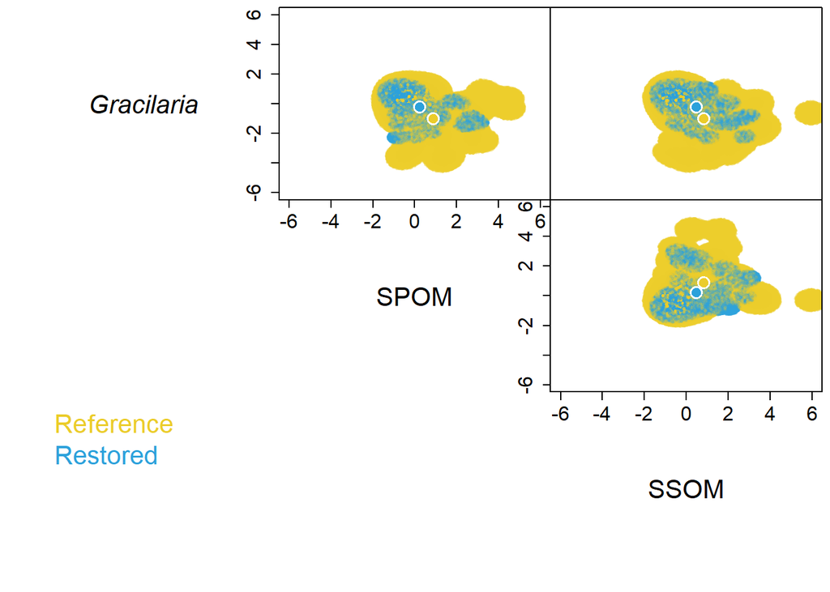

```r
# Plot oyster data
hvOY= hypervolume_join(ref_hv, res_hv)

plot(hvOY, pairplot = T, colors=c("#EBCC2A","#2ca1db"),
     names= c(expression(italic("Gracilaria"),"SPOM", "SSOM")),
     show.3d=FALSE,plot.3d.axes.id=NULL,
     show.axes=TRUE, show.frame=TRUE,
     show.random=T, show.density=TRUE,show.data=F,
     show.legend=T, limits=c(-6,6),
     show.contour=F, contour.lwd= 2,
     contour.type='alphahull',
     contour.alphahull.alpha=0.25,
     contour.ball.radius.factor=1,
     contour.kde.level=0.01,
     contour.raster.resolution=100,
     show.centroid=TRUE, cex.centroid=2,
     point.alpha.min=0.2, point.dark.factor=0.5,
     cex.random=0.5,cex.data=1,cex.axis=1.5,cex.names=2,cex.legend=2,
     num.points.max.data = 100000, num.points.max.random = 200000, reshuffle=TRUE,
     plot.function.additional=NULL,
     verbose=FALSE
)
```

### Calulating trophic breadth

The function `hypervolume::get_volume()` can be used to calculate the trophic breadth or variation in resource use of the food web

```r
# Reference food web
get_volume(ref_hv)
```

```
## Reference
##  100.0157
```

```r
# Restored food web
get_volume(res_hv)
```

```
## Restored
## 22.41691
```

### Calculate overlap

Overlap is a measure of the similarity between two hypervolumes. It takes into account both the position and the size of the hypervolumes. So to have high overlap, the hypervolumes need to be both similar in size and located in the same *n*-dimensional space.

To calculate overlap, hypevolumes need to be joined with `hypervolume::hypervolume_set()`. To calculate the metrics `hypervolume::hypervolume_overlap_statistics()`. This function calculates 4 metrics that are related to the overlap of the two hypervolumes

*jaccard*: Jaccard similarity (volume of intersection of 1 and 2 divided by volume of union of 1 and 2)

*sorensen*: Sorensen similarity (twice the volume of intersection of 1 and 2 divided by volume of 1 plus volume of 2)

*fraq_uniq_1*: Unique fraction of hypervolume 1 (volume of unique component of 1 divided by volume of 1))

*fraq_uniq_2*: Unique fraction of hypervolume 2 (volume of unique component of 2 divided by volume of 2))

```r
# join hypervolumes
set = hypervolume_set(ref_hv, res_hv, check.memory = F, verbose = F)
```

```
##
## Building tree...
## done.
## Ball query...
##
## done.
##
## Building tree...
## done.
## Ball query...
##
## done.
```

```r
# calculate overlap
hypervolume_overlap_statistics(set)
```

```
##       jaccard      sorensen frac_unique_1 frac_unique_2
##     0.1934539     0.3241916     0.8015730     0.1146945
```

### Calculate percent recovery of food web

In restoration, a system is considered recovered as it becomes similar to the reference system or a specific target. This can be easily calculated with hypervolumes by determining the overlap between the reference and restored food web hypervolumes. However, given that there is inherent variability between systems, [James et al. 2019](https://doi.org/10.1016/j.scitotenv.2019.134801) developed a method, perecent recovery ($\%_{recovery}$), to compare overlap between two hypervolumes to the overlap of two randomly hypervolumes generated from the same data.
$$\%_{recovery} = SO_{hab}/SO_{rand}$$
$SO_{hab}$ = Sorensen overlap of the reference and restored habitats, $SO_{rand}$ = Sorensen overlap of the 2 random hypervolumes

```r
# create random overlap from data
# randomly assign data to make hvs
hvs = bind_rows(ref_df, res_df)
sub = sample(nrow(hvs),nrow(res_df))
df1 = hvs[sub,]
df2 = hvs[-sub,]

# generate random hv 1
hv1 = hypervolume_gaussian(df1, name = 'hv1',
                             #samples.per.point = ceiling((10^(3 + sqrt(ncol(df1))))/nrow(df1)),
                             samples.per.point = 5000,
                             kde.bandwidth = estimate_bandwidth(df1),
                             sd.count = 3,
                             quantile.requested = 0.95,
                             quantile.requested.type = "probability",
                             chunk.size = 1000,
                             verbose = F)

hv2 = hypervolume_gaussian(df2, name = 'hv2',
                             #samples.per.point = ceiling((10^(3 + sqrt(ncol(df2))))/nrow(df2)),
                             samples.per.point = 5000,
                             kde.bandwidth = estimate_bandwidth(df2),
                             sd.count = 3,
                             quantile.requested = 0.95,
                             quantile.requested.type = "probability",
                             chunk.size = 1000,
                             verbose = F)
# join hypervolumes
set_rand = hypervolume_set(hv1, hv2, check.memory = F, verbose = F)
```

```
##
## Building tree...
## done.
## Ball query...
##
## done.
##
## Building tree...
## done.
## Ball query...
##
## done.
```

```r
SO_hab = hypervolume_overlap_statistics(set)[2]
SO_rand = hypervolume_overlap_statistics(set_rand)[2]

# calulate %recovery
SO_hab/SO_rand * 100
```

```
## sorensen
## 53.19934
```

### Repeat process to calculate confidence intervals

To calculate confidence intervals, the above steps can be repeated *n* times. This can easily be done with a `for` loop.

```r
# number or iterations
n = 50


# create tibble to store data
df_hvAll = tibble(rep = rep(seq(1,n,1)),
                  ref_vol = NA, res_vol= NA,
                  sorensen = NA, randOV = NA)



for (i in 1:n){
  # generate random from mean and sd that are z-scored
  oy = HVvalues(df = df, ID_rows = c('name','site'),names = c('source'),
                mean = 'mean', sd = 'sd', n = 20,
                end_points = T, low = 'lowend', high = 'highend',
                z_score = T)

  # Reference hypervolume
  # subset reference data
  ref_df = oy %>% filter(site == 'Reference')%>%
    select(-name, -site)

  # generate hypervolume
  ref_hv = hypervolume_gaussian(ref_df, name = 'Reference',
                                #samples.per.point = ceiling((10^(3 + sqrt(ncol(ref_df))))/nrow(ref_df)),
                                samples.per.point = 5000,
                                kde.bandwidth = estimate_bandwidth(ref_df),
                                sd.count = 3,
                                quantile.requested = 0.95,
                                quantile.requested.type = "probability",
                                chunk.size = 1000,
                                verbose = F)

  # get reference volume
  df_hvAll$ref_vol[i] = get_volume(ref_hv)


  # subset restoration data
  res_df = oy %>% filter(site == 'Restored') %>%
    select(-name, -site)

  # generate restored hypervolume
  res_hv = hypervolume_gaussian(res_df, name = 'Restored',
                                #samples.per.point = ceiling((10^(3 + sqrt(ncol(res_df))))/nrow(res_df)),
                                samples.per.point = 5000,
                                kde.bandwidth = estimate_bandwidth(res_df),
                                sd.count = 3,
                                quantile.requested = 0.95,
                                quantile.requested.type = "probability",
                                chunk.size = 1000,
                                verbose = F)
  # get restoration volume
  df_hvAll$res_vol[i] = get_volume(res_hv)

  # join hypervolumes
  set = hypervolume_set(ref_hv, res_hv, check.memory = F, verbose = F)

  # calculate sorensen overlap
  df_hvAll$sorensen[i] = hypervolume_overlap_statistics(set)[2]

  # create random overlap from data
  # randomly assign data to make hvs
  hvs = bind_rows(ref_df, res_df)
  sub = sample(nrow(hvs),nrow(res_df))
  df1 = hvs[sub,]
  df2 = hvs[-sub,]

  # generate random hv 1
  hv1 = hypervolume_gaussian(df1, name = 'hv1',
                             #samples.per.point = ceiling((10^(3 + sqrt(ncol(df1))))/nrow(df1)),
                             samples.per.point = 5000,
                             kde.bandwidth = estimate_bandwidth(df1),
                             sd.count = 3,
                             quantile.requested = 0.95,
                             quantile.requested.type = "probability",
                             chunk.size = 1000,
                             verbose = F)

  hv2 = hypervolume_gaussian(df2, name = 'hv2',
                             #samples.per.point = ceiling((10^(3 + sqrt(ncol(df2))))/nrow(df2)),
                             samples.per.point = 5000,
                             kde.bandwidth = estimate_bandwidth(df2),
                             sd.count = 3,
                             quantile.requested = 0.95,
                             quantile.requested.type = "probability",
                             chunk.size = 1000,
                             verbose = F)
  # join hypervolumes
  set_rand = hypervolume_set(hv1, hv2, check.memory = F, verbose = F)

  # calculate overlap
  df_hvAll$randOV[i] = hypervolume_overlap_statistics(set_rand)[2]

}

# calculate percent recovery
df_hvALL = df_hvALL %>% mutate(rec = sorensen/randOV)

df_hvALL
```

[output not shown]

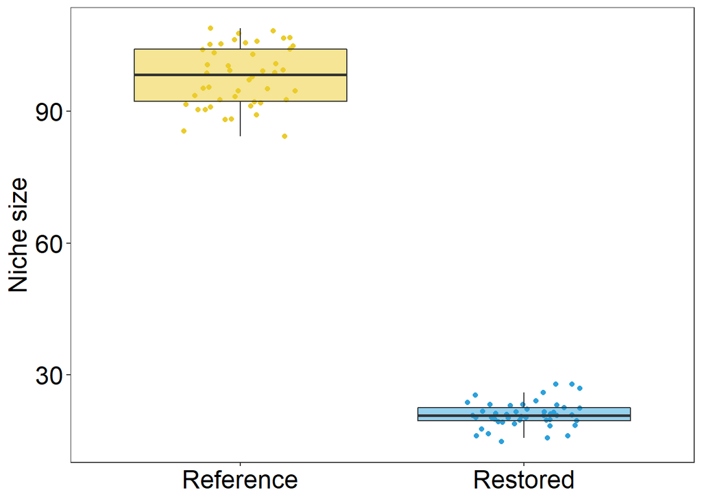

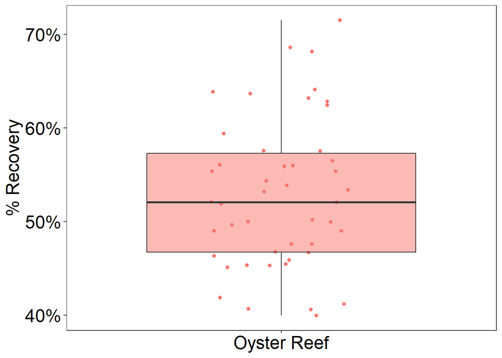